# act_report

```python
#import libraries

import pandas as pd
import numpy as np
import tweepy
import requests
import json
import matplotlib.pyplot as plt
import seaborn as sb
%matplotlib inline
```

```python
#load the final dataset
master_data = pd.read_csv('twitter_archive_master.csv')
```

## Insight 1

### 1.Which breed has maximum count in prediction 1 column?

```python
#calculate the counts of dog's type in predection 1 by using value count function
master_data.prediction_1.value_counts()
```

```
golden_retriever      150
Labrador_retriever     97
Pembroke               88
Chihuahua              81
pug                    57
                     ...
flamingo                1
coho                    1
beach_wagon             1
shopping_basket         1
three-toed_sloth        1
Name: prediction_1, Length: 378, dtype: int64
```

### So from output it's clear that golden retriever has maximum number of prediction 1 count.

## Insight 2

### 2. what's the correlation bettwen number of retweets and number of favorite ?

[figure not shown]

```python
#Plot scatter plot between favorite count and retweet count
plt.scatter(data=master_data,x='retweet_count',y='favorite_count',alpha=0.7)
plt.xlabel('number of favorites')
plt.ylabel('number of retweets')
plt.title("Scatter plot between favorite count and retweet count")
```

### There is a positive correlation between favorite count and retweet count,thus with increase in the number of favorite, we can see that number of retweet also increases.

## Insight 3

### 3. Which stage of dog got more number of tweets?

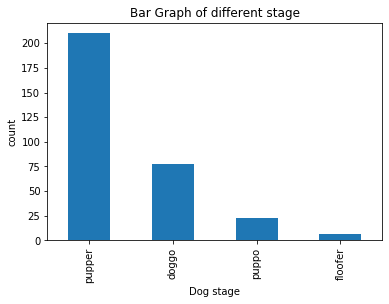

```python
#plot bar graph of Dog's stage
master_data.dog_stage.value_counts().plot(kind='bar')
plt.xlabel('Dog stage')
plt.ylabel('count')
plt.title("Bar Graph of different stage")
```

### Pupper stage dogs got more than 200 tweets.Hence pupper got most of the tweets.

## Insight 4

### 4. Which breed of dog got Maximum number of retweets and favorites count?

```python
#Sort retweet count in descending order
master_data.sort_values(by='retweet_count',ascending=False)['prediction_1']
```

```
26           Labrador_retriever
24                   Eskimo_dog
663                   Chihuahua
307            Lakeland_terrier
369            English_springer
                 ...
2030    black-and-tan_coonhound
1928                   web_site
460                  pencil_box
2022     curly-coated_retriever
2042             English_setter
Name: prediction_1, Length: 2059, dtype: object
```

```python
master_data.sort_values(by='favorite_count',ascending=False)['prediction_1']
```

```
26     Labrador_retriever
307      Lakeland_terrier
663             Chihuahua
228        French_bulldog
24             Eskimo_dog
              ...
677                  chow
949               upright
283               doormat
789              Cardigan
316            dishwasher
Name: prediction_1, Length: 2059, dtype: object
```

## Conclusion

1.Golden retriever has maximum number of prediction 1 count.

2.There is a positive correlation between favorite count and retweet count,thus with increase in the number of favorite, we can see that number of retweet also increases.

3.Pupper stage dogs got more than 200 tweets.Hence pupper got most of the tweets.